# Boundary Area Closure Trigger Assessment - 2022

Justin Priest

23 May 2022

# RMarkdown Document Notes

The text below is from a deliverable to the Pacific Salmon Commission. Some data have been omitted for brevity and confidentiality. This entire document was written in R using RMarkdown to create this file.

# Overview & Background

The [2019 PSC Treaty](https://www.psc.org/publications/pacific-salmon-treaty/) Attachment B states that “If the Alaska Fisheries Performance District (”FPD”) Area 6 troll fishery statistical week 27, 28 and 29 average catch per boat day is” less than 22, there will be closures in both Alaskan and Canadian waters of varying duration and geographical range, depending on CPUE (0-10; 10-14; 15-22).

That is, inseason management of the Boundary Area Coho fishery for both US and Canada is guided by US Troll fishermen in US Districts 101 and 102 (“Area 6”). This was based on observations that historically, US Troll CPUE was correlated to fishery wild abundance.

This document addresses potential improvements to these treaty triggers.

## US Troll CPUE: Early vs all weeks

Does US troll CPUE in early weeks predict the CPUE for the rest of the season? Let’s compare how it looks both with and without Stat Week 30.

### Weeks 27–29

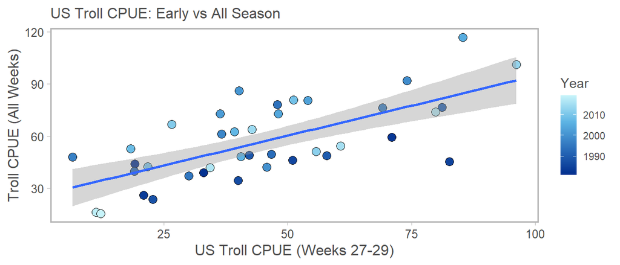

```r
# US CPUE data includes 1981-2000 data
troll81to19 <- UStroll_cpue %>%
  filter(District == "101" | District == "102",
         StatWeek <= 29,
         !StatArea %in% termareas) %>% # exclude terminal harvest areas
  group_by(Year) %>%
  summarise(UStrollCPUE = mean(CohoCPUE),
            numtrips = n_distinct(TripNumber))

troll81to19allweeks <- UStroll_cpue %>%
  filter(District == "101" | District == "102") %>%
  filter(!StatArea %in% termareas) %>% # exclude terminal harvest areas
  group_by(Year) %>%
  summarise(UStrollCPUEallwk = mean(CohoCPUE),
            USnumtripsallwk = n_distinct(TripNumber))

# Does troll CPUE in early weeks predict the CPUE for the rest of the season?
troll81to19 %>%
  left_join(troll81to19allweeks) %>%
  ggplot(aes(x=UStrollCPUE, y=UStrollCPUEallwk, fill=Year)) +
  geom_point(pch = 21, color="black", size = 3) +
  geom_smooth(method = "lm") +
  scale_fill_adfg("glacier", discrete = FALSE) +
  labs(x = "US Troll CPUE (Weeks 27-29)", y = "Troll CPUE (All Weeks)",
       title = "US Troll CPUE: Early vs All Season")  +
  theme_crisp(base_family = "Arial")
```

```r
troll81to19 %>%
  left_join(troll81to19allweeks) %>%
  lm(UStrollCPUEallwk ~ UStrollCPUE, data = .) %>% broom::tidy()
```

```
## # A tibble: 2 × 5
##   term        estimate std.error statistic    p.value
##   <chr>          <dbl>     <dbl>     <dbl>      <dbl>
## 1 (Intercept)   26.0       5.98       4.34 0.000105
## 2 UStrollCPUE    0.688     0.119      5.77 0.00000128
```

### Weeks 27–30

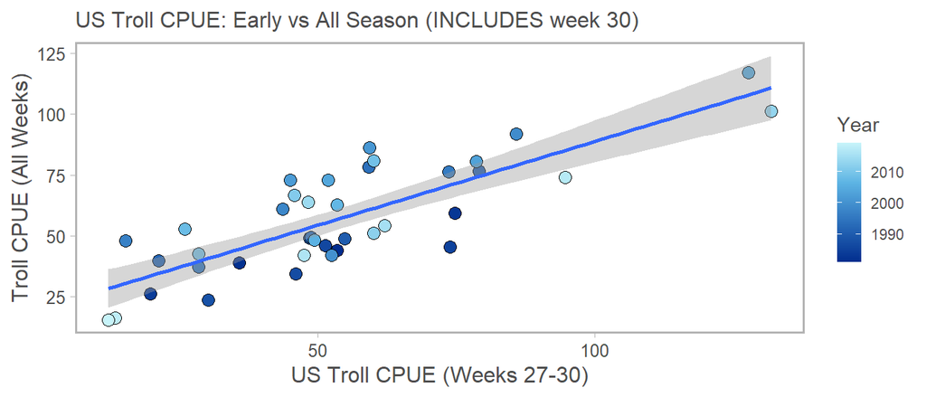

```r
troll81to19wk30 <- UStroll_cpue %>%
  filter(District == "101" | District == "102",
         StatWeek <= 30,
         !StatArea %in% termareas) %>% # exclude terminal harvest areas
  group_by(Year) %>%
  summarise(UStrollCPUEwk30 = mean(CohoCPUE))

troll81to19wk30 %>%
  left_join(troll81to19allweeks) %>%
  ggplot(aes(x=UStrollCPUEwk30, y=UStrollCPUEallwk, fill=Year)) +
  geom_point(pch = 21, color="black", size = 3) +
  geom_smooth(method = "lm") +
  scale_fill_adfg("glacier", discrete = FALSE) +
  labs(x = "US Troll CPUE (Weeks 27-30)", y = "Troll CPUE (All Weeks)",
       title = "US Troll CPUE: Early vs All Season (INCLUDES week 30)") +
  theme_crisp(base_family = "Arial")
```

```r
troll81to19wk30 %>%
  left_join(troll81to19allweeks) %>%
  lm(UStrollCPUEallwk ~ UStrollCPUEwk30, data = .) %>% broom::tidy()
```

```
## # A tibble: 2 × 5
##   term            estimate std.error statistic  p.value
##   <chr>              <dbl>     <dbl>     <dbl>    <dbl>
## 1 (Intercept)       19.8      4.77        4.16 1.81e- 4
## 2 UStrollCPUEwk30    0.690    0.0796      8.67 1.95e-10
```

Yes. They are significantly positively associated. We can see a much tighter relationship when we include Stat Week 30.

## US Troll CPUE vs US wild abundance

Note that this is wild coho abundance for all of Southeast Alaska, not just the boundary area.

### Weeks 27–29

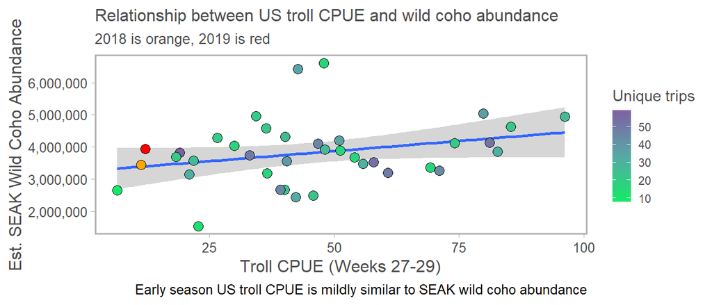

```r
# Not currently used (this is only 2000-2019 data!)
troll_boundannual <- troll_boundary %>%
  filter(!StatArea %in% termareas) %>% # exclude terminal harvest areas
  group_by(Year) %>%
  summarise(UStrollCPUE = mean(CohoCPUE))

UStrollcpue_wildabund <- wildabundance %>%
  #filter(Year >= 2000) %>% # uncomment this for final
  filter(Year <= maxyear) %>%
  left_join(troll81to19) # replace with troll_boundannual for final


ggplot(UStrollcpue_wildabund, aes(x=UStrollCPUE, y = EstTotalWildAbund, fill = numtrips)) +
  #geom_text(aes(label = Year)) +
  geom_smooth(method = "lm") +
  geom_point(size = 3, pch = 21, color = "black") +
  geom_point(data = UStrollcpue_wildabund %>% filter(Year == 2019),
             aes(x=UStrollCPUE, y = EstTotalWildAbund), pch = 21, size = 3, color = "black", fill = "red") +
  geom_point(data = UStrollcpue_wildabund %>% filter(Year == 2018),
             aes(x=UStrollCPUE, y = EstTotalWildAbund), pch = 21, size = 3, color = "black", fill = "orange") +
  scale_y_continuous(labels = scales::comma) +
  scale_fill_adfg("aurora", discrete = FALSE) +
  labs(x = "Troll CPUE (Weeks 27-29)", y = "Est. SEAK Wild Coho Abundance",
       title = "Relationship between US troll CPUE and wild coho abundance",
       subtitle = "2018 is orange, 2019 is red",
       caption = "Early season US troll CPUE is mildly similar to SEAK wild coho abundance",
       fill = "Unique trips")  +
  theme_crisp(base_family = "Arial")
```

```r
lm(EstTotalWildAbund ~ UStrollCPUE, weights = numtrips, data = UStrollcpue_wildabund) %>% broom::tidy()
```

```
## # A tibble: 2 × 5
##   term        estimate std.error statistic  p.value
##   <chr>          <dbl>     <dbl>     <dbl>    <dbl>
## 1 (Intercept) 3381084.   324440.     10.4  2.04e-12
## 2 UStrollCPUE    9369.     6296.      1.49 1.45e- 1
```

### Weeks 27–30

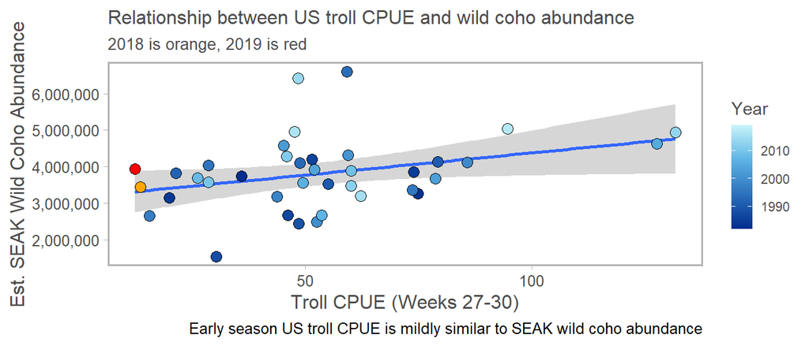

```r
UStrollcpue_wildabundwk30 <- wildabundance %>%
  #filter(Year >= 2000) %>% # uncomment this for final
  filter(Year <= maxyear) %>%
  left_join(troll81to19wk30) # replace with troll_boundannual for final


ggplot(UStrollcpue_wildabundwk30, aes(x=UStrollCPUEwk30, y = EstTotalWildAbund, fill = Year)) +
  #geom_text(aes(label = Year)) +
  geom_smooth(method = "lm") +
  geom_point(size = 3, pch = 21, color = "black") +
  geom_point(data = UStrollcpue_wildabundwk30 %>% filter(Year == 2019),
             aes(x=UStrollCPUEwk30, y = EstTotalWildAbund), pch = 21, size = 3, color = "black", fill = "red") +
  geom_point(data = UStrollcpue_wildabundwk30 %>% filter(Year == 2018),
             aes(x=UStrollCPUEwk30, y = EstTotalWildAbund), pch = 21, size = 3, color = "black", fill = "orange") +
  scale_y_continuous(labels = scales::comma) +
  scale_fill_adfg("glacier", discrete = FALSE) +
  labs(x = "Troll CPUE (Weeks 27-30)", y = "Est. SEAK Wild Coho Abundance",
       title = "Relationship between US troll CPUE and wild coho abundance",
       subtitle = "2018 is orange, 2019 is red",
       caption = "Early season US troll CPUE is mildly similar to SEAK wild coho abundance",
       fill = "Year")  +
  theme_crisp(base_family = "Arial")
```

```r
lm(EstTotalWildAbund ~ UStrollCPUEwk30, data = UStrollcpue_wildabundwk30) %>% broom::tidy()
```

```
## # A tibble: 2 × 5
##   term            estimate std.error statistic  p.value
##   <chr>              <dbl>     <dbl>     <dbl>    <dbl>
## 1 (Intercept)     3168011.   341422.      9.28 4.41e-11
## 2 UStrollCPUEwk30   12115.     5690.      2.13 4.02e- 2
```

# Prelim Background Charts

Here we explore the background of some alternative sources of inseason coho salmon indicators. We have three alternative projects: the [Tyee Test Fishery (Canada)](https://www.pac.dfo-mpo.gc.ca/fm-gp/northcoast-cotenord/skeenatyee-eng.html), the [Nass River Fishwheels (Canada)](https://www.pac.dfo-mpo.gc.ca/fm-gp/northcoast-cotenord/nass-eng.html), and the Hugh Smith Lake weir (Alaska). Of these, Hugh Smith Lake was found early on to not be useful for predicting troll CPUE; background plots will not be shown for Hugh Smith Lake.

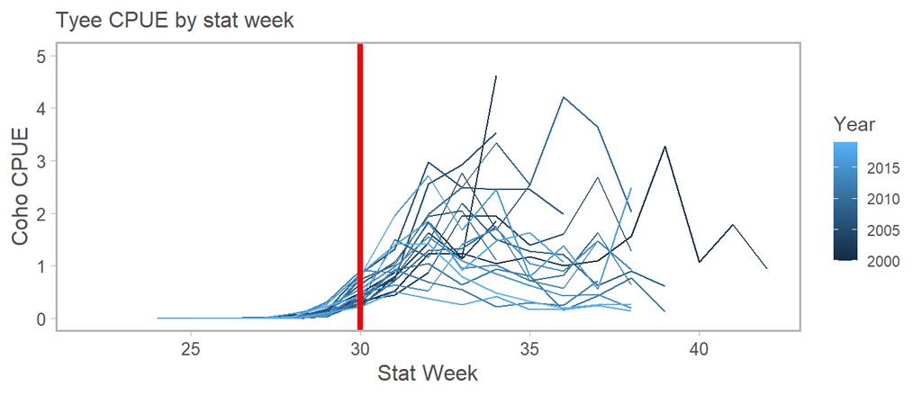

```r
# I had this in there and it's a great viz but is duplicative
# ggplot(tyeecpue, aes(x = Std_date, y = CohoCPUE, color = Year, group = Year)) +
#   geom_smooth(se = F) +
#   scale_y_continuous(limits = c(0, 10)) +
#   labs(title = "Tyee CPUE over time, smoothed", x = "", y = "Coho CPUE")

ggplot(tyee_weekly %>% filter(Year >= 2000), aes(x = week, y = Tyee_cpue, color = Year, group = Year)) +
  geom_line() +
  geom_vline(xintercept = 30, color = "red", size = 1.5) +
  scale_y_continuous(limits = c(0, 5)) +
  labs(title = "Tyee CPUE by stat week", x = "Stat Week", y = "Coho CPUE") +
  theme_crisp(base_family = "Arial")
```

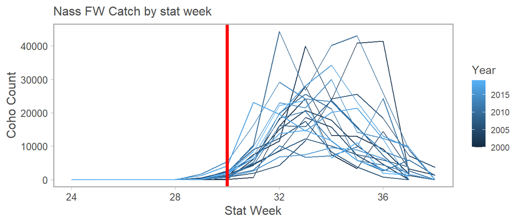

```r
ggplot(NassFW_weekly, aes(x=week, y = Nass_coho, group = Year, color = Year)) +
  geom_line() +
  geom_vline(xintercept = 30, color = "red", size = 1.5) +
  labs(title = "Nass FW Catch by stat week", x = "Stat Week", y = "Coho Count") +
  theme_crisp(base_family = "Arial")
```

# Modeling

```r
mod_nass <- lm(UStrollCPUE ~ Nass_coho, data = indices_2000)
mod_tyee <- lm(UStrollCPUE ~ Tyee_cpue, data = indices_2000)
mod_NBCtroll <- lm(UStrollCPUE ~ NBCtrollcount, data = indices_2000)
mod_nasswk <- lm(UStrollCPUE ~ Nass_coho + week, data = indices_2000)
mod_tyeewk <- lm(UStrollCPUE ~ Tyee_cpue + week, data = indices_2000)
mod_NBCtrollwk <- lm(UStrollCPUE ~ NBCtrollcount + week, data = indices_2000)
mod_nasstyee <- lm(UStrollCPUE ~ Nass_coho + Tyee_cpue, data = indices_2000)

# Dec 7 Update: Remove the lead1 variables as they're confusing
# mod_nasslead <- lm(UStrollCPUE ~ Nass_coho_lead1, data = indices_2000)
# mod_tyeelead <- lm(UStrollCPUE ~ Tyee_cpue_lead1, data = indices_2000)




#summary(mod_nass) #
#summary(mod_tyee) #
#summary(mod_nasstyee) # much collinearity, but improves fit
#summary(mod_nasslead) # fairly good indicator
#summary(mod_tyeelead) # not as good as Nass lead1
#summary(mod_nasswk)
#summary(mod_tyeewk)


modelcomparisons <- tibble(`Model Formula` =
                             c(paste0(mod_nass$call)[2],
                               paste0(mod_tyee$call)[2],
                               paste0(mod_NBCtroll$call)[2],
                               paste0(mod_nasstyee$call)[2],
                               paste0(mod_nasswk$call)[2],
                               paste0(mod_tyeewk$call)[2],
                               paste0(mod_NBCtrollwk$call)[2])) %>%
  add_column(
    rbind(broom::glance(mod_nass) %>% dplyr::select(AIC, adj.r.squared, p.value),
          broom::glance(mod_tyee) %>% dplyr::select(AIC, adj.r.squared, p.value),
          broom::glance(mod_NBCtroll) %>% dplyr::select(AIC, adj.r.squared, p.value),
          broom::glance(mod_nasstyee) %>% dplyr::select(AIC, adj.r.squared, p.value),
          broom::glance(mod_nasswk) %>% dplyr::select(AIC, adj.r.squared, p.value),
          broom::glance(mod_tyeewk) %>% dplyr::select(AIC, adj.r.squared, p.value),
          broom::glance(mod_NBCtrollwk) %>% dplyr::select(AIC, adj.r.squared, p.value)) %>%
      mutate(p.value = round(p.value, 3),
             p.value = ifelse(p.value < 0.001, "<0.001", p.value)))


modelcomparisons %>%
  mutate_at(c("AIC", "adj.r.squared"), round, 2) %>%
  knitr::kable() %>%
  kable_styling(bootstrap_options = c("striped", "hover", "condensed")) %>%
  kable_paper() %>% kableExtra::kable_styling(full_width = F) %>%
  row_spec(3, bold = T, color = "black", background = "#fff194")
```

| Model Formula | AIC | adj.r.squared | p.value |
| --- | --- | --- | --- |
| UStrollCPUE ~ Nass_coho | 529.45 | 0.22 | <0.001 |
| UStrollCPUE ~ Tyee_cpue | 523.52 | 0.30 | <0.001 |
| UStrollCPUE ~ NBCtrollcount | 456.11 | 0.16 | 0.004 |
| UStrollCPUE ~ Nass_coho + Tyee_cpue | 524.79 | 0.30 | <0.001 |
| UStrollCPUE ~ Nass_coho + week | 516.60 | 0.40 | <0.001 |
| UStrollCPUE ~ Tyee_cpue + week | 519.60 | 0.36 | <0.001 |
| UStrollCPUE ~ NBCtrollcount + week | 447.07 | 0.32 | <0.001 |

## Top Model Diagnostics

The top single variable model using no lag was the model with the Tyee Fishery data. Below are some summary output and diagnostics from the top model:

```r
topmod <- mod_tyee
summary(topmod)
```

```
##
## Call:
## lm(formula = UStrollCPUE ~ Tyee_cpue, data = indices_2000)
##
## Residuals:
##     Min      1Q  Median      3Q     Max
## -66.917 -17.767  -5.786   9.504 145.355
##
## Coefficients:
##             Estimate Std. Error t value Pr(>|t|)
## (Intercept)   32.865      5.703   5.763 4.81e-07 ***
## Tyee_cpue    286.238     59.281   4.829 1.29e-05 ***
## ---
## Signif. codes:  0 '***' 0.001 '**' 0.01 '*' 0.05 '.' 0.1 ' ' 1
##
## Residual standard error: 32.54 on 51 degrees of freedom
##   (7 observations deleted due to missingness)
## Multiple R-squared:  0.3137, Adjusted R-squared:  0.3003
## F-statistic: 23.31 on 1 and 51 DF,  p-value: 1.294e-05
```

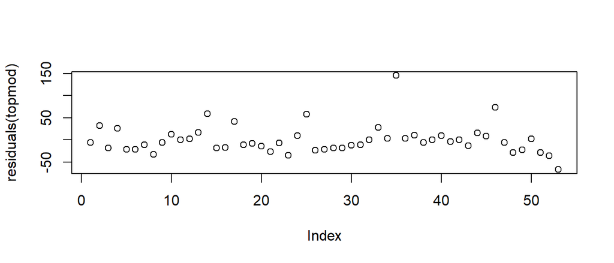

```r
plot(residuals(topmod))
```

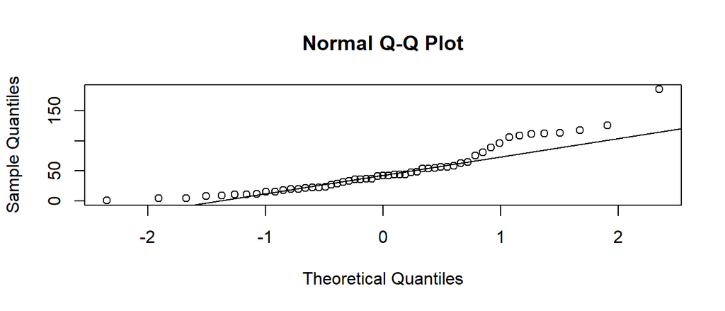

```r
qqnorm(indices_2000$UStrollCPUE)
qqline(indices_2000$UStrollCPUE)
```

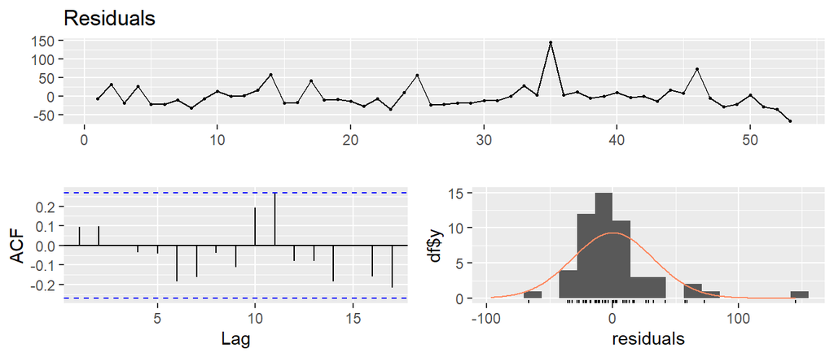

```
##
##  Breusch-Godfrey test for serial correlation of order up to 10
##
## data:  Residuals
## LM test = 7.5062, df = 10, p-value = 0.6769
```

```r
checkresiduals(topmod) # from package "forecast"
```

# RECOMMENDATIONS